# TÜİK Forecasting Project – Motor Land Vehicles Statistics

# 6 Forecasting Methods

```r
# Accuracy function used throughout
calc_accuracy <- function(actual, fitted) {
  valid <- !is.na(actual) & !is.na(fitted)
  a <- actual[valid]; f <- fitted[valid]
  if (length(a) == 0) return(rep(NA, 6))
  e    <- a - f
  bias <- mean(e)
  mad  <- mean(abs(e))
  mse  <- mean(e^2)
  mape <- mean(abs(e / a)) * 100
  rsfe <- sum(e)
  ts_v <- rsfe / mad
  c(Bias=bias, MAD=mad, MSE=mse, MAPE=mape, RSFE=rsfe, TS=ts_v)
}
```

## 6.1 Naïve Forecasting

```r
naive_fit    <- naive(ts_vehicles)
naive_fitted <- as.numeric(fitted(naive_fit))
naive_fc     <- as.numeric(forecast(naive_fit, h=1)$mean)
acc_naive    <- calc_accuracy(actual_vec, naive_fitted)
cat("Naïve forecast:", format(round(naive_fc), big.mark=","), "\n")
```

```
## Naïve forecast: 182,034
```

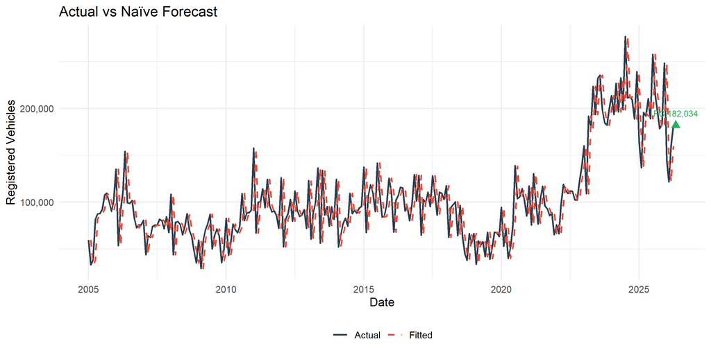

Actual vs Naïve Forecast

```r
df_n <- data.frame(date=date_vec, Actual=actual_vec, Fitted=naive_fitted) %>%
  pivot_longer(-date, names_to="series", values_to="value")
ggplot(df_n, aes(x=date, y=value, colour=series, linetype=series)) +
  geom_line(na.rm=TRUE, linewidth=0.8) +
  annotate("point", x=forecast_date, y=naive_fc, colour="#27AE60", size=3, shape=17) +
  annotate("text", x=forecast_date, y=naive_fc*1.07,
           label=paste0("FC:",format(round(naive_fc),big.mark=",")), size=3, colour="#27AE60") +
  scale_colour_manual(values=c("Actual"="#2C3E50","Fitted"="#E74C3C")) +
  scale_linetype_manual(values=c("Actual"="solid","Fitted"="dashed")) +
  scale_y_continuous(labels=comma) +
  labs(title="Actual vs Naïve Forecast", x="Date", y="Registered Vehicles",
       colour=NULL, linetype=NULL) +
  theme_minimal(base_size=12) + theme(legend.position="bottom")
```

```r
ggsave("outputs/figures/naive_forecast_plot.png", width=10, height=5, dpi=150)
```

**Interpretation**: Naïve method uses the last observation as forecast. It is the baseline — useful for comparison but ignores trend and seasonality entirely.

## 6.2 Moving Average (k = 3)

```r
k_ma <- 3
ma_fitted <- rep(NA, n_obs)
for (i in (k_ma+1):n_obs) ma_fitted[i] <- mean(actual_vec[(i-k_ma):(i-1)])
ma_fc  <- mean(actual_vec[(n_obs-k_ma+1):n_obs])
acc_ma <- calc_accuracy(actual_vec, ma_fitted)
cat("MA(3) forecast:", format(round(ma_fc), big.mark=","), "\n")
```

```
## MA(3) forecast: 154,585
```

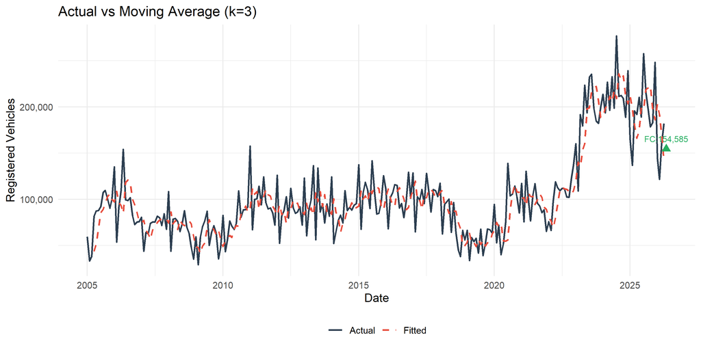

Actual vs Moving Average (k=3)

```r
df_ma <- data.frame(date=date_vec, Actual=actual_vec, Fitted=ma_fitted) %>%
  pivot_longer(-date, names_to="series", values_to="value")
ggplot(df_ma, aes(x=date, y=value, colour=series, linetype=series)) +
  geom_line(na.rm=TRUE, linewidth=0.8) +
  annotate("point", x=forecast_date, y=ma_fc, colour="#27AE60", size=3, shape=17) +
  annotate("text", x=forecast_date, y=ma_fc*1.07,
           label=paste0("FC:",format(round(ma_fc),big.mark=",")), size=3, colour="#27AE60") +
  scale_colour_manual(values=c("Actual"="#2C3E50","Fitted"="#E74C3C")) +
  scale_linetype_manual(values=c("Actual"="solid","Fitted"="dashed")) +
  scale_y_continuous(labels=comma) +
  labs(title="Actual vs Moving Average (k=3)", x="Date", y="Registered Vehicles",
       colour=NULL, linetype=NULL) +
  theme_minimal(base_size=12) + theme(legend.position="bottom")
```

```r
ggsave("outputs/figures/moving_average_plot.png", width=10, height=5, dpi=150)
```

**Interpretation**: A 3-month window balances responsiveness and smoothing. Does not capture seasonality but reduces noise compared to naïve.

## 6.3 Weighted Moving Average

```r
raw_w  <- c(1, 2, 3)
w      <- raw_w / sum(raw_w)
k_wma  <- length(w)
wma_fitted <- rep(NA, n_obs)
for (i in (k_wma+1):n_obs) wma_fitted[i] <- sum(w * actual_vec[(i-k_wma):(i-1)])
wma_fc  <- sum(w * actual_vec[(n_obs-k_wma+1):n_obs])
acc_wma <- calc_accuracy(actual_vec, wma_fitted)
cat("WMA forecast:", format(round(wma_fc), big.mark=","), "| weights:", paste(round(w,3), collapse=", "), "\n")
```

```
## WMA forecast: 164,626 | weights: 0.167, 0.333, 0.5
```

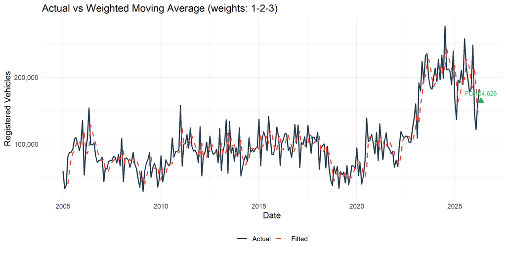

Actual vs Weighted Moving Average

```r
df_wma <- data.frame(date=date_vec, Actual=actual_vec, Fitted=wma_fitted) %>%
  pivot_longer(-date, names_to="series", values_to="value")
ggplot(df_wma, aes(x=date, y=value, colour=series, linetype=series)) +
  geom_line(na.rm=TRUE, linewidth=0.8) +
  annotate("point", x=forecast_date, y=wma_fc, colour="#27AE60", size=3, shape=17) +
  annotate("text", x=forecast_date, y=wma_fc*1.07,
           label=paste0("FC:",format(round(wma_fc),big.mark=",")), size=3, colour="#27AE60") +
  scale_colour_manual(values=c("Actual"="#2C3E50","Fitted"="#E74C3C")) +
  scale_linetype_manual(values=c("Actual"="solid","Fitted"="dashed")) +
  scale_y_continuous(labels=comma) +
  labs(title="Actual vs Weighted Moving Average (weights: 1-2-3)",
       x="Date", y="Registered Vehicles", colour=NULL, linetype=NULL) +
  theme_minimal(base_size=12) + theme(legend.position="bottom")
```

```r
ggsave("outputs/figures/weighted_moving_average_plot.png", width=10, height=5, dpi=150)
```

**Interpretation**: Weights 1-2-3 give more importance to recent months, which is appropriate since recent market conditions better reflect upcoming registrations.

## 6.4 Exponential Smoothing

```r
ses_fit    <- ets(ts_vehicles, model="ANN")
ses_alpha  <- ses_fit$par["alpha"]
ses_fitted <- as.numeric(fitted(ses_fit))
ses_fc     <- as.numeric(forecast(ses_fit, h=1)$mean)
acc_ses    <- calc_accuracy(actual_vec, ses_fitted)
cat("SES alpha:", round(ses_alpha,4), "| forecast:", format(round(ses_fc), big.mark=","), "\n")
```

```
## SES alpha: 0.3326 | forecast: 170,381
```

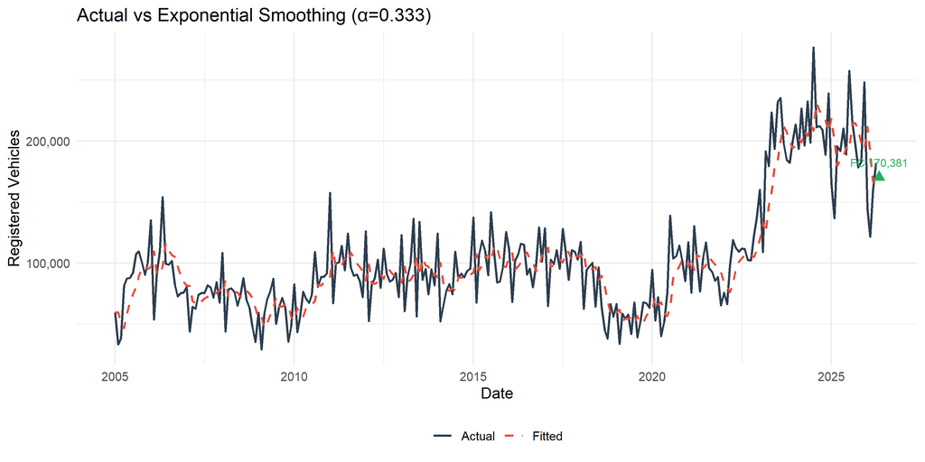

Actual vs Exponential Smoothing

```r
df_ses <- data.frame(date=date_vec, Actual=actual_vec, Fitted=ses_fitted) %>%
  pivot_longer(-date, names_to="series", values_to="value")
ggplot(df_ses, aes(x=date, y=value, colour=series, linetype=series)) +
  geom_line(na.rm=TRUE, linewidth=0.8) +
  annotate("point", x=forecast_date, y=ses_fc, colour="#27AE60", size=3, shape=17) +
  annotate("text", x=forecast_date, y=ses_fc*1.07,
           label=paste0("FC:",format(round(ses_fc),big.mark=",")), size=3, colour="#27AE60") +
  scale_colour_manual(values=c("Actual"="#2C3E50","Fitted"="#E74C3C")) +
  scale_linetype_manual(values=c("Actual"="solid","Fitted"="dashed")) +
  scale_y_continuous(labels=comma) +
  labs(title=paste0("Actual vs Exponential Smoothing (α=",round(ses_alpha,3),")"),
       x="Date", y="Registered Vehicles", colour=NULL, linetype=NULL) +
  theme_minimal(base_size=12) + theme(legend.position="bottom")
```

```r
ggsave("outputs/figures/exponential_smoothing_plot.png", width=10, height=5, dpi=150)
```

**Interpretation**: Optimal α selected by maximum likelihood. Higher α = more reactive to recent changes. Ignores trend and seasonality.

## 6.5 Trend-Adjusted Exponential Smoothing (Holt’s)

```r
# Series has meaningful trend → Holt's method is applicable
holt_fit    <- ets(ts_vehicles, model="AAN")
holt_alpha  <- holt_fit$par["alpha"]
holt_beta   <- holt_fit$par["beta"]
holt_fitted <- as.numeric(fitted(holt_fit))
holt_fc     <- as.numeric(forecast(holt_fit, h=1)$mean)
acc_holt    <- calc_accuracy(actual_vec, holt_fitted)
cat("Holt alpha:", round(holt_alpha,4), "| beta:", round(holt_beta,4),
    "| forecast:", format(round(holt_fc), big.mark=","), "\n")
```

```
## Holt alpha: 0.2821 | beta: 0.0228 | forecast: 168,476
```

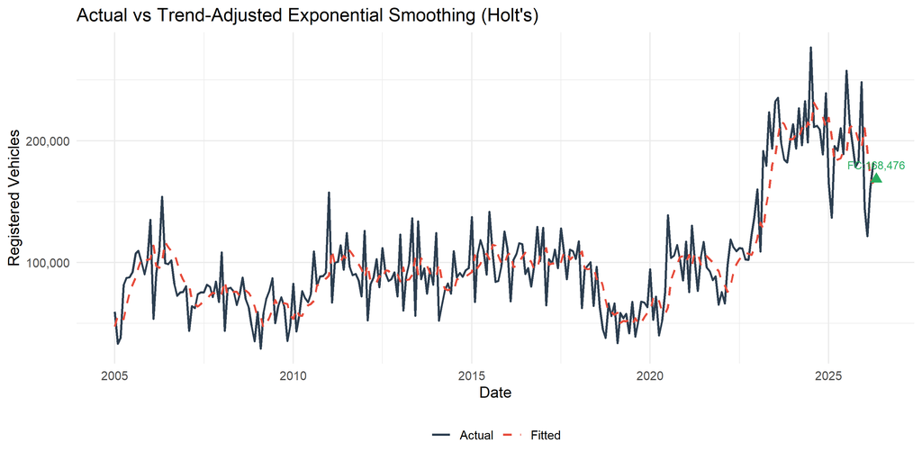

Actual vs Trend-Adjusted Exponential Smoothing

```r
df_holt <- data.frame(date=date_vec, Actual=actual_vec, Fitted=holt_fitted) %>%
  pivot_longer(-date, names_to="series", values_to="value")
ggplot(df_holt, aes(x=date, y=value, colour=series, linetype=series)) +
  geom_line(na.rm=TRUE, linewidth=0.8) +
  annotate("point", x=forecast_date, y=holt_fc, colour="#27AE60", size=3, shape=17) +
  annotate("text", x=forecast_date, y=holt_fc*1.07,
           label=paste0("FC:",format(round(holt_fc),big.mark=",")), size=3, colour="#27AE60") +
  scale_colour_manual(values=c("Actual"="#2C3E50","Fitted"="#E74C3C")) +
  scale_linetype_manual(values=c("Actual"="solid","Fitted"="dashed")) +
  scale_y_continuous(labels=comma) +
  labs(title="Actual vs Trend-Adjusted Exponential Smoothing (Holt's)",
       x="Date", y="Registered Vehicles", colour=NULL, linetype=NULL) +
  theme_minimal(base_size=12) + theme(legend.position="bottom")
```

```r
ggsave("outputs/figures/trend_adjusted_smoothing_plot.png", width=10, height=5, dpi=150)
```

**Interpretation**: Holt’s method captures the trend component (β) in addition to the level (α). Captures trend but not seasonality.

## 6.6 Linear Trend Projection

```r
t_vec    <- 1:n_obs
lm_trend <- lm(actual_vec ~ t_vec)
lm_fitted <- as.numeric(fitted(lm_trend))
lm_fc     <- as.numeric(predict(lm_trend, newdata=data.frame(t_vec=n_obs+1)))
acc_lm    <- calc_accuracy(actual_vec, lm_fitted)
cat("Equation: Y =", round(coef(lm_trend)[1],1), "+",
    round(coef(lm_trend)[2],1), "* t\n")
```

```
## Equation: Y = 54577.9 + 382.3 * t
```

```r
cat("Slope interpretation: approx.", round(coef(lm_trend)[2],0),
    "additional registrations per month on average\n")
```

```
## Slope interpretation: approx. 382 additional registrations per month on average
```

```r
cat("Forecast:", format(round(lm_fc), big.mark=","), "\n")
```

```
## Forecast: 152,835
```

```r
summary(lm_trend)
```

```
##
## Call:
## lm(formula = actual_vec ~ t_vec)
##
## Residuals:
##    Min     1Q Median     3Q    Max
## -85548 -23401  -3372  20224 132191
##
## Coefficients:
##             Estimate Std. Error t value Pr(>|t|)
## (Intercept) 54577.91    4897.68   11.14   <2e-16 ***
## t_vec         382.33      33.04   11.57   <2e-16 ***
## ---
## Signif. codes:  0 '***' 0.001 '**' 0.01 '*' 0.05 '.' 0.1 ' ' 1
##
## Residual standard error: 39070 on 254 degrees of freedom
## Multiple R-squared:  0.3452, Adjusted R-squared:  0.3426
## F-statistic: 133.9 on 1 and 254 DF,  p-value: < 2.2e-16
```

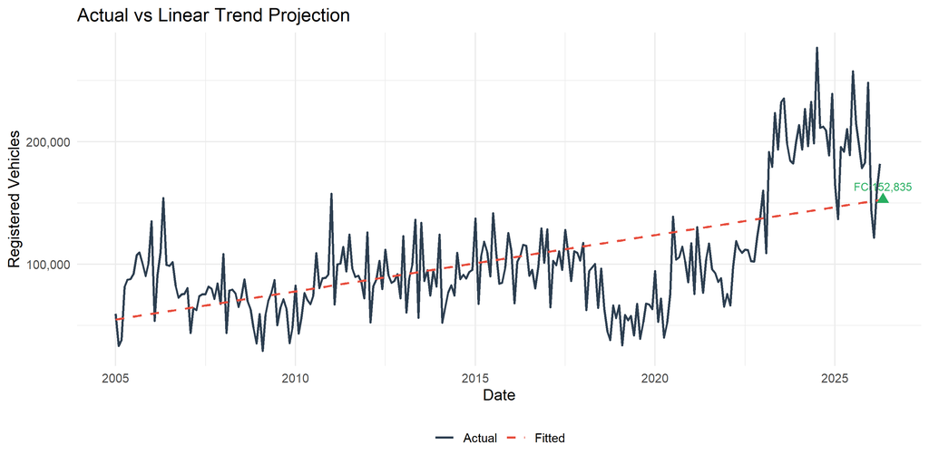

Actual vs Linear Trend Projection

```r
df_lm <- data.frame(date=date_vec, Actual=actual_vec, Fitted=lm_fitted) %>%
  pivot_longer(-date, names_to="series", values_to="value")
ggplot(df_lm, aes(x=date, y=value, colour=series, linetype=series)) +
  geom_line(na.rm=TRUE, linewidth=0.8) +
  annotate("point", x=forecast_date, y=lm_fc, colour="#27AE60", size=3, shape=17) +
  annotate("text", x=forecast_date, y=lm_fc*1.07,
           label=paste0("FC:",format(round(lm_fc),big.mark=",")), size=3, colour="#27AE60") +
  scale_colour_manual(values=c("Actual"="#2C3E50","Fitted"="#E74C3C")) +
  scale_linetype_manual(values=c("Actual"="solid","Fitted"="dashed")) +
  scale_y_continuous(labels=comma) +
  labs(title="Actual vs Linear Trend Projection",
       x="Date", y="Registered Vehicles", colour=NULL, linetype=NULL) +
  theme_minimal(base_size=12) + theme(legend.position="bottom")
```

```r
ggsave("outputs/figures/trend_projection_plot.png", width=10, height=5, dpi=150)
```

**Interpretation**: Captures the long-run trend but misses seasonal fluctuations, resulting in systematic errors within each year.

## 6.7 Seasonal Indices

```r
season_vec <- cycle(ts_vehicles)

# Centred moving average
cma   <- stats::filter(actual_vec, rep(1/freq, freq), sides=2)
ratio <- actual_vec / cma

# Average seasonal index per month
si <- tapply(ratio, season_vec, mean, na.rm=TRUE)
si <- si / mean(si)

cat("Seasonal Indices:\n")
```

```
## Seasonal Indices:
```

```r
si_df <- data.frame(Month=month.abb, Index=round(si,4))
kable(si_df, caption="Seasonal Indices (Multiplicative)") %>%
  kable_styling(bootstrap_options="striped", full_width=FALSE)
```

Seasonal Indices (Multiplicative)

| Month | Index |
| --- | --- |
| Jan | 1.2115 |
| Feb | 0.6564 |
| Mar | 0.9963 |
| Apr | 1.0135 |
| May | 1.1077 |
| Jun | 0.9609 |
| Jul | 1.1844 |
| Aug | 1.0538 |
| Sep | 0.9661 |
| Oct | 0.9484 |
| Nov | 0.9736 |
| Dec | 0.9273 |

```r
cat("High-season:", month.abb[which.max(si)], "(", round(max(si),3), ")\n")
```

```
## High-season: Jan ( 1.212 )
```

```r
cat("Low-season :", month.abb[which.min(si)], "(", round(min(si),3), ")\n")
```

```
## Low-season : Feb ( 0.656 )
```

```r
# Deseasonalised trend
deseas    <- actual_vec / si[season_vec]
lm_deseas <- lm(deseas ~ t_vec)
b0d <- coef(lm_deseas)[1]; b1d <- coef(lm_deseas)[2]
si_fitted <- (b0d + b1d * t_vec) * si[season_vec]

next_season <- (n_obs %% freq) + 1
si_fc <- (b0d + b1d*(n_obs+1)) * si[next_season]
acc_si <- calc_accuracy(actual_vec, si_fitted)
cat("SI forecast:", format(round(si_fc), big.mark=","), "\n")
```

```
## SI forecast: 171,239
```

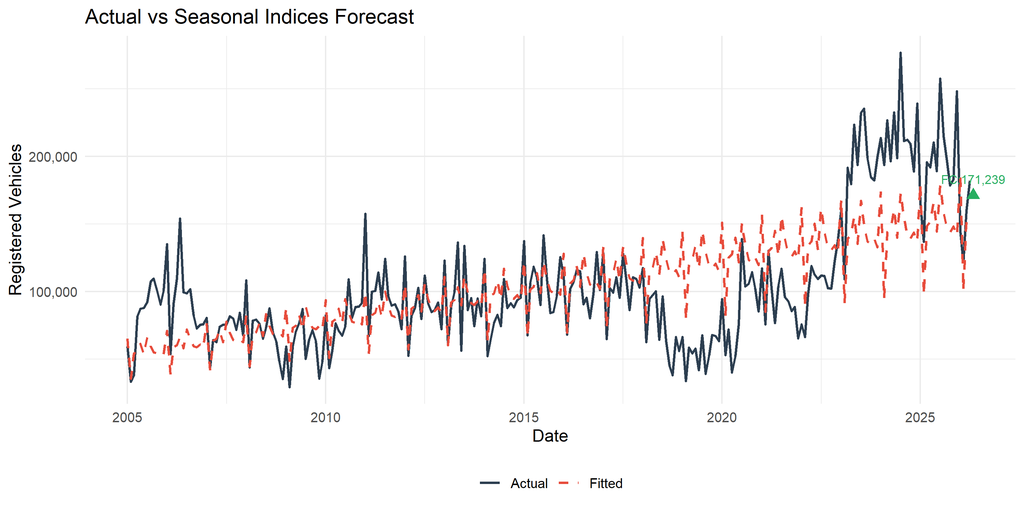

Actual vs Seasonal Indices Forecast

```r
df_si <- data.frame(date=date_vec, Actual=actual_vec, Fitted=si_fitted) %>%
  pivot_longer(-date, names_to="series", values_to="value")
ggplot(df_si, aes(x=date, y=value, colour=series, linetype=series)) +
  geom_line(na.rm=TRUE, linewidth=0.8) +
  annotate("point", x=forecast_date, y=si_fc, colour="#27AE60", size=3, shape=17) +
  annotate("text", x=forecast_date, y=si_fc*1.07,
           label=paste0("FC:",format(round(si_fc),big.mark=",")), size=3, colour="#27AE60") +
  scale_colour_manual(values=c("Actual"="#2C3E50","Fitted"="#E74C3C")) +
  scale_linetype_manual(values=c("Actual"="solid","Fitted"="dashed")) +
  scale_y_continuous(labels=comma) +
  labs(title="Actual vs Seasonal Indices Forecast",
       x="Date", y="Registered Vehicles", colour=NULL, linetype=NULL) +
  theme_minimal(base_size=12) + theme(legend.position="bottom")
```

```r
ggsave("outputs/figures/seasonal_indices_plot.png", width=10, height=5, dpi=150)
```

**Interpretation**: Captures both trend and seasonality by combining a trend regression on deseasonalised data with monthly seasonal indices.

## 6.8 Additive Decomposition

```r
dec_add      <- decompose(ts_vehicles, type="additive")
trend_add    <- as.numeric(dec_add$trend)
seasonal_add <- as.numeric(dec_add$seasonal)

valid_a  <- !is.na(trend_add)
t_sub_a  <- t_vec[valid_a]
lm_add   <- lm(trend_add[valid_a] ~ t_sub_a)
b0a <- coef(lm_add)[1]; b1a <- coef(lm_add)[2]

add_fitted <- (b0a + b1a*t_vec) + seasonal_add
add_fc     <- (b0a + b1a*(n_obs+1)) + seasonal_add[(n_obs%%freq)+1]
acc_add    <- calc_accuracy(actual_vec, add_fitted)
cat("Additive decomp forecast:", format(round(add_fc), big.mark=","), "\n")
```

```
## Additive decomp forecast: 161,980
```

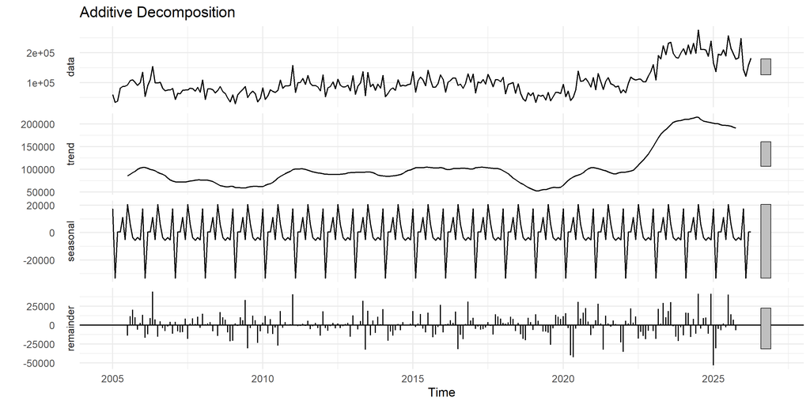

```r
autoplot(dec_add) + labs(title="Additive Decomposition") + theme_minimal(base_size=11)
```

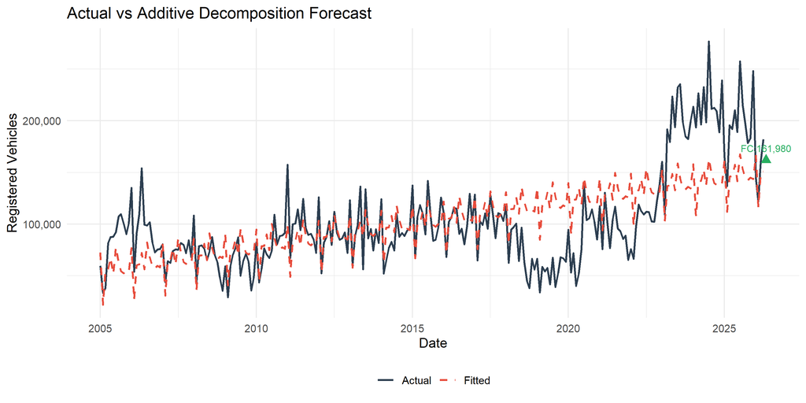

Actual vs Additive Fitted

```r
df_add <- data.frame(date=date_vec, Actual=actual_vec, Fitted=add_fitted) %>%
  pivot_longer(-date, names_to="series", values_to="value")
ggplot(df_add, aes(x=date, y=value, colour=series, linetype=series)) +
  geom_line(na.rm=TRUE, linewidth=0.8) +
  annotate("point", x=forecast_date, y=add_fc, colour="#27AE60", size=3, shape=17) +
  annotate("text", x=forecast_date, y=add_fc*1.07,
           label=paste0("FC:",format(round(add_fc),big.mark=",")), size=3, colour="#27AE60") +
  scale_colour_manual(values=c("Actual"="#2C3E50","Fitted"="#E74C3C")) +
  scale_linetype_manual(values=c("Actual"="solid","Fitted"="dashed")) +
  scale_y_continuous(labels=comma) +
  labs(title="Actual vs Additive Decomposition Forecast",
       x="Date", y="Registered Vehicles", colour=NULL, linetype=NULL) +
  theme_minimal(base_size=12) + theme(legend.position="bottom")
```

```r
ggsave("outputs/figures/additive_decomposition_plot.png", width=10, height=5, dpi=150)
```

## 6.9 Multiplicative Decomposition

```r
dec_mult      <- decompose(ts_vehicles, type="multiplicative")
trend_mult    <- as.numeric(dec_mult$trend)
seasonal_mult <- as.numeric(dec_mult$seasonal)

valid_m  <- !is.na(trend_mult)
t_sub_m  <- t_vec[valid_m]
lm_mult  <- lm(trend_mult[valid_m] ~ t_sub_m)
b0m <- coef(lm_mult)[1]; b1m <- coef(lm_mult)[2]

mult_fitted <- (b0m + b1m*t_vec) * seasonal_mult
mult_fc     <- (b0m + b1m*(n_obs+1)) * seasonal_mult[(n_obs%%freq)+1]
acc_mult    <- calc_accuracy(actual_vec, mult_fitted)
cat("Multiplicative decomp forecast:", format(round(mult_fc), big.mark=","), "\n")
```

```
## Multiplicative decomp forecast: 166,946
```

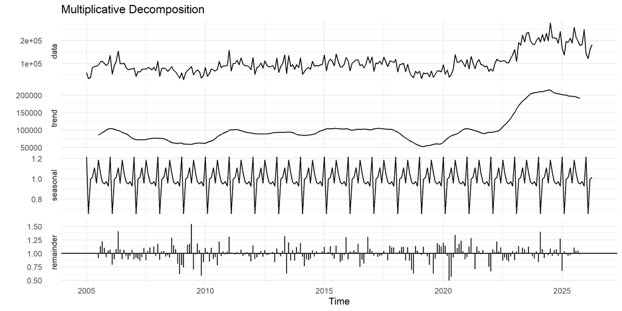

```r
autoplot(dec_mult) + labs(title="Multiplicative Decomposition") + theme_minimal(base_size=11)
```

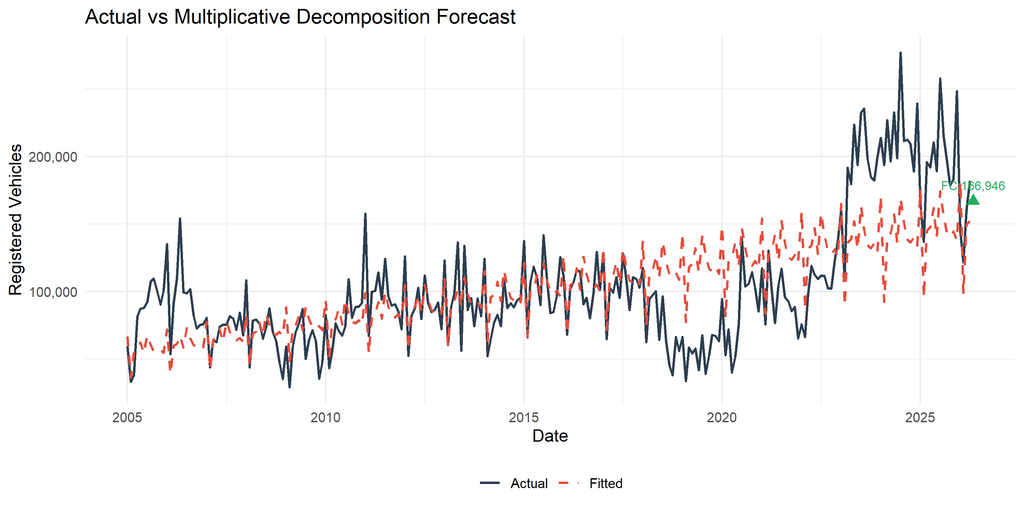

Actual vs Multiplicative Fitted

```r
df_mult <- data.frame(date=date_vec, Actual=actual_vec, Fitted=mult_fitted) %>%
  pivot_longer(-date, names_to="series", values_to="value")
ggplot(df_mult, aes(x=date, y=value, colour=series, linetype=series)) +
  geom_line(na.rm=TRUE, linewidth=0.8) +
  annotate("point", x=forecast_date, y=mult_fc, colour="#27AE60", size=3, shape=17) +
  annotate("text", x=forecast_date, y=mult_fc*1.07,
           label=paste0("FC:",format(round(mult_fc),big.mark=",")), size=3, colour="#27AE60") +
  scale_colour_manual(values=c("Actual"="#2C3E50","Fitted"="#E74C3C")) +
  scale_linetype_manual(values=c("Actual"="solid","Fitted"="dashed")) +
  scale_y_continuous(labels=comma) +
  labs(title="Actual vs Multiplicative Decomposition Forecast",
       x="Date", y="Registered Vehicles", colour=NULL, linetype=NULL) +
  theme_minimal(base_size=12) + theme(legend.position="bottom")
```

```r
ggsave("outputs/figures/multiplicative_decomposition_plot.png", width=10, height=5, dpi=150)
```